# Pilot K-means Analysis

Full year monthly SST

- test the feasibility of using k-means clustering on SST images to capture seasonal changes and the evolution of patterns over time.
- explore different ways to approach the problem
- decide on next steps

Summary

- k-means clustering can capture the shapes
- removing the mean likely better because otherwise centers are too influenced by mean temperature
- hierarchical clustering of the centers seems a reasonable way to come up with main groups from a larger K

Next steps

- Explore different K to see how big of a K is needed to capture the seasonal structure and shift that happens in June.

## Read in the data

Function to read in a csv file of SST. Four columns: date, lat, lon, SST.

```r
processCSV <- function(file, aspect_ratio, lat_range, long_range){
  library(dplyr)

#constants
pixels <- prod(aspect_ratio)
dates <- length(unique(dat$date))

#reads the file. Maps out dates
dat <- read.table(file, sep=",", skip=2)
colnames(dat) <- c("date", "lat", "lon", "sst")
dat$date <- as.Date(dat$date)

# limit to certain box
not.box <- dat$lat < lat_range[1] | dat$lat>lat_range[2] | dat$lon<long_range[1] | dat$lon>long_range[2]
dat.box <- dat[!not.box, ]
n.by.date <- tapply(dat.box$sst, dat.box$date, function(x){sum(is.na(x))})
if(any((n.by.date-n.by.date[1])!=0)) stop("There's a problem. Should be same n for each date.")

dat.wide <- pivot_wider(dat.box, names_from=date, values_from=sst)
pos.loc <- which(!is.na(dat.wide[,3])) # which row are NA?
dat.clean <- na.omit(dat.wide) # remove the rows that are NA

# Note transpose since kmeans() wants variates in columns
return(list(dat=t(dat.wide), dat.clean=t(dat.clean), pos.loc=pos.loc))
}
```

Read in the data. Run once and then saved to an RData file. The data is a matrix where each row is a date (month) and each column is a pixel. The image has been unwrapped into a vector. The first 2 rows of the matrix are the lat and lon values for the pixels.

```r
datafile <- file.path(here::here(), "data", "SEAS-monthly-sst.RData")
# file <- 'data/hawaii_soest_d124_2bb9_c935-5-27-48-80-1979-01-01-2020-06-01.csv'
# aspect_ratio <- c(89,129)
# lat_range <- c(7,13)
# long_range <- c(72,78)
# out <- processCSV(file=file, aspect_ratio=aspect_ratio,
#                       lat_range=lat_range,
#                       long_range=long_range)
# save(out, file=datafile)
load(datafile)
```

Set up the data and data features. `Data_clean` are the images without the NAs (land) and `Data_dirty` has the NAs. The latter will be need to reconstruct the images from the centroids. `pos_loc` is the indices of the non-NA values and is used to reconstruct the images.

```r
Data_clean <- out$dat.clean
Data_dirty <- out$dat
pos_loc <- out$pos.loc
```

Data clean and meta data. Remove the lat/lon rows and change to Celcius.

```r
lats <- Data_dirty[1,]
lons <- Data_dirty[2,]
asp <- c(table(lons)[1], table(lats)[1]) # lon (x) - lats (y)
bb.box <- c(min(lons), max(lons), min(lats), max(lats))
```

## Create matrices for `kmeans()`

We will use the non-normalized and normalized data. Need to remove the first 2 rows since those are the lat/lon values. For normalization, we use `scale()`. `scale()` normalizes (removes mean and standardizes to variance 1) by column, but we need to normalize each date (row) not each pixel (column). So need to transpose. Also in the context of these images, we don’t want to scale (i.e. stretch) the images but I add that for comparison.

```r
X <- Data_clean[c(-1,-2),] - 273.15
X_norm <- scale(t(X), scale=FALSE)
X_norm <- t(X_norm)
X_norm_sd <- t(scale(t(X)))
```

## Plot K versus SS

Plot the total within sum of squares for a range of K (number of centroids).

```r
findK <- function(X, nstart=25, iter.max=10, n_K=15){
cost <- rep(0, n_K)
for(k in  1:n_K)
  cost[k] <- kmeans(X, k, iter.max=iter.max, nstart=nstart)$tot.withinss
plot(1:n_K, cost, xlab="K", ylab="total within ss", type="b")
}
```

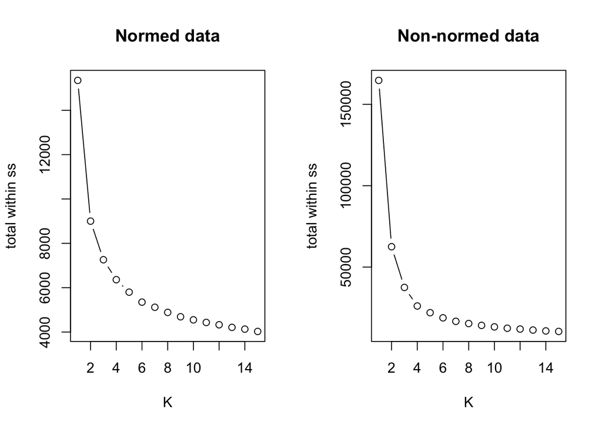

```r
par(mfrow=c(1,2))
findK(X_norm, nstart=25, iter.max=10, n_K=15)
abline(h=12)
title("Normed data")
findK(X, nstart=25, iter.max=10, n_K=15)
abline(h=12)
title("Non-normed data")
```

For the pilot analysis, set K = 12. Some relatively big to try to capture the variability.

```r
n_K <- 12
iter.max <- 25
nstart <- 100
```

## Create centroid raster stack

Get centroids for normed data using the `kmeans()` function in base R.

```r
set.seed(1221966)
out_kmeans_norm <- kmeans(X_norm, n_K, iter.max=iter.max, nstart=nstart)
```

Create the centroid images. Need to add back in the NAs.

```r
centroid_images <- matrix(NA, n_K, ncol(Data_dirty))
centroid_images[, pos_loc] <- out_kmeans_norm$centers
rownames(centroid_images) <- paste("Centroid", 1:n_K)
```

Make the centroid images into a raster stack (**raster** package).

```r
library(raster)
```

```r
img.list <- list()
img.mat <- centroid_images
for(i in 1:nrow(img.mat)){
  # file is lat1, lat1, ..., lat1, lat2, lat2, ... so byrow=TRUE
  # lat 7 is S and lat 13 is N; lat 72 is W and lat 78 is E
  # asp is c(lons (x/cols), lats (y/rows))
  tmp <- matrix(img.mat[i,], asp[2], asp[1], byrow=TRUE)
  tmp <- tmp[asp[2]:1, ] # lat 7 at bottom not top
  tmp <- raster(tmp)
  extent(tmp) <- bb.box
  img.list[[i]] <- tmp
}
img.list.norm <- img.list
centroid_stack <- stack(img.list)
names(centroid_stack) <- paste("Centroid", 1:n_K)
crs(centroid_stack) <- "+proj=longlat +datum=WGS84"
```

## Centroids

### Normed Data

Make the plot using **tmap** package. One could just plot with **raster** but **tmap** is more flexible.

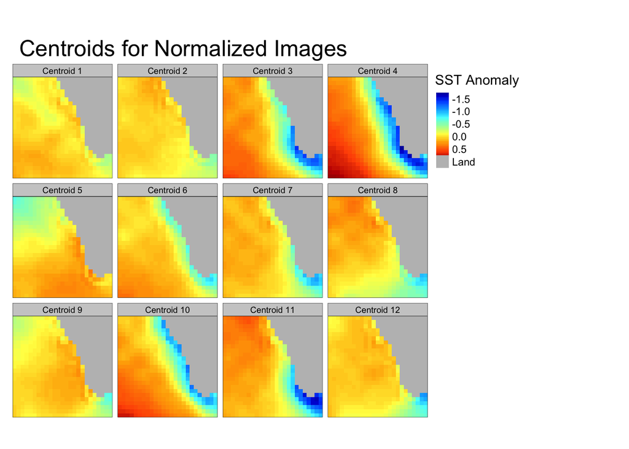

```r
library(tmap)
pal <- topo.colors(100)
pal <- colorRamps::matlab.like(100)
tm_shape(centroid_stack) +
  tm_raster(style= "cont", title="SST Anomaly",
            palette=pal, midpoint=NA,
            colorNA = "grey", textNA = "Land") +
  tm_layout(panel.labels = paste("Centroid", 1:n_K)) +
  tm_layout(main.title = "Centroids for Normalized Images", title.size = 1)
```

### Non-Normed Data

Repeat the code above but for `X` the non-normed matrix.

```r
set.seed(1221966)
out_kmeans <- kmeans(X, n_K, iter.max=iter.max, nstart=nstart)
```

In this plot, all the images are on the same SST scale. This makes it easy to see the upwelling pattern (cold next to coast), but makes is hard to see there is a pattern with a colder northern tongue and cold tip but different mean temperature.

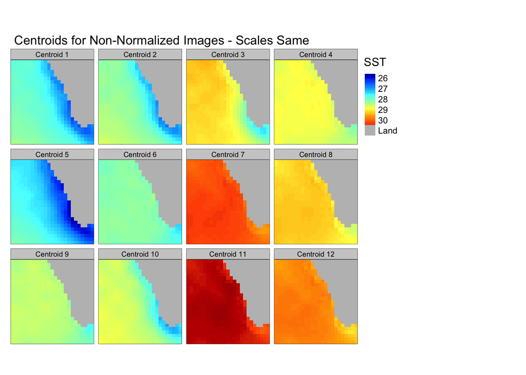

That pattern is easy to see if all the images are on a different scale, but now it is not clear that the images have different mean temperatures.

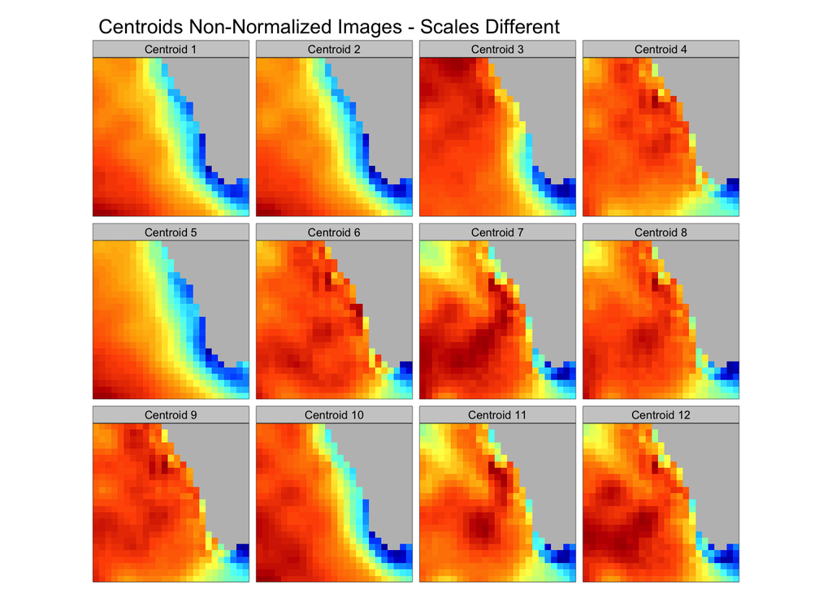

### Normed and Variance standardized Data

Repeat the code above but for `X` normed and variance standardized matrix.

```r
set.seed(1221966)
out_kmeans_sd <- kmeans(X_norm_sd, n_K, iter.max=iter.max, nstart=nstart)
```

The centroid images. Note images were demeaned and standardized to variance of 1.

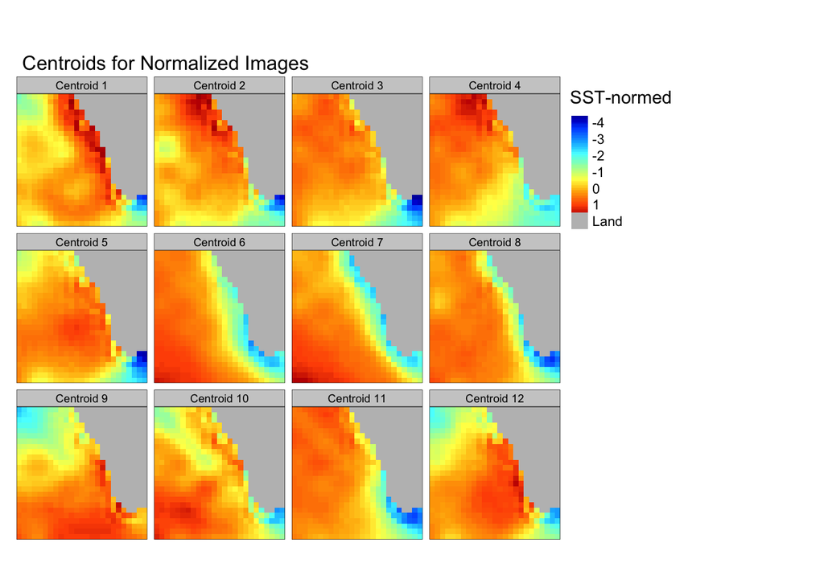

## Distance between images

Here I use hierarchical clustering on the distances between clusters.

### Normed clusters

```r
CC <- out_kmeans_norm$centers
labs <- paste0("C", 1:n_K, "  ", round(apply(CC,1,mean)-mean(CC),digits=1))
rownames(CC) <- labs
```

Distance based on correlation. The `dendIMG()` function is shown below.

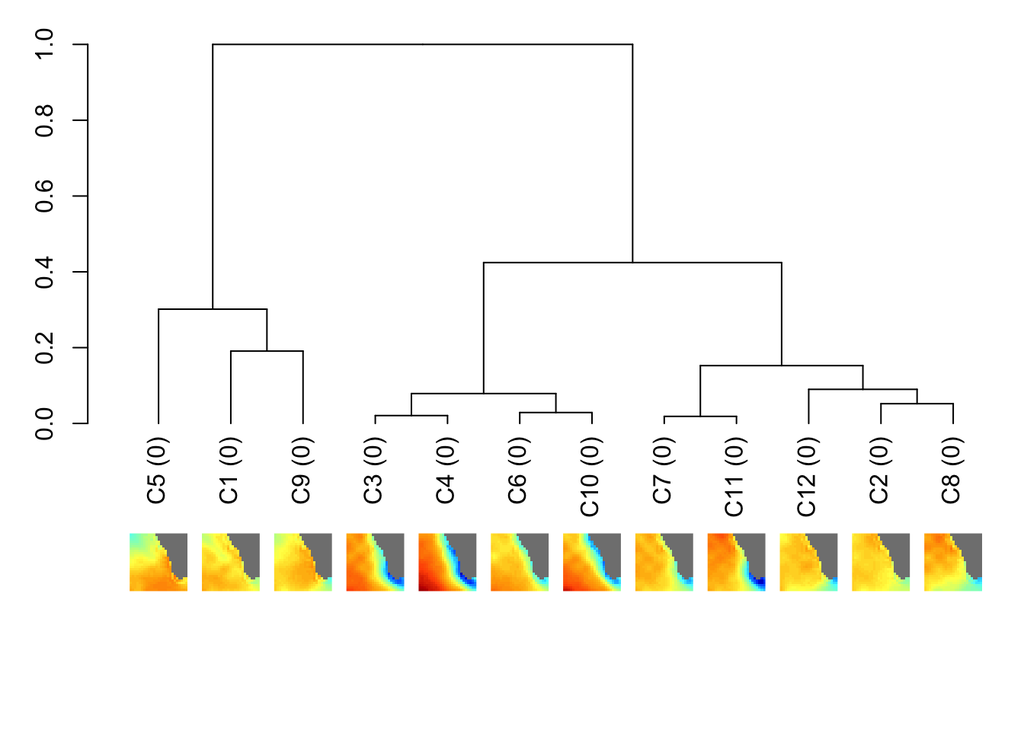

```r
dendIMG(CC, img.list.norm, type="correlation", pal=pal, scale.same=TRUE)
```

Here the distance is Euclidian.

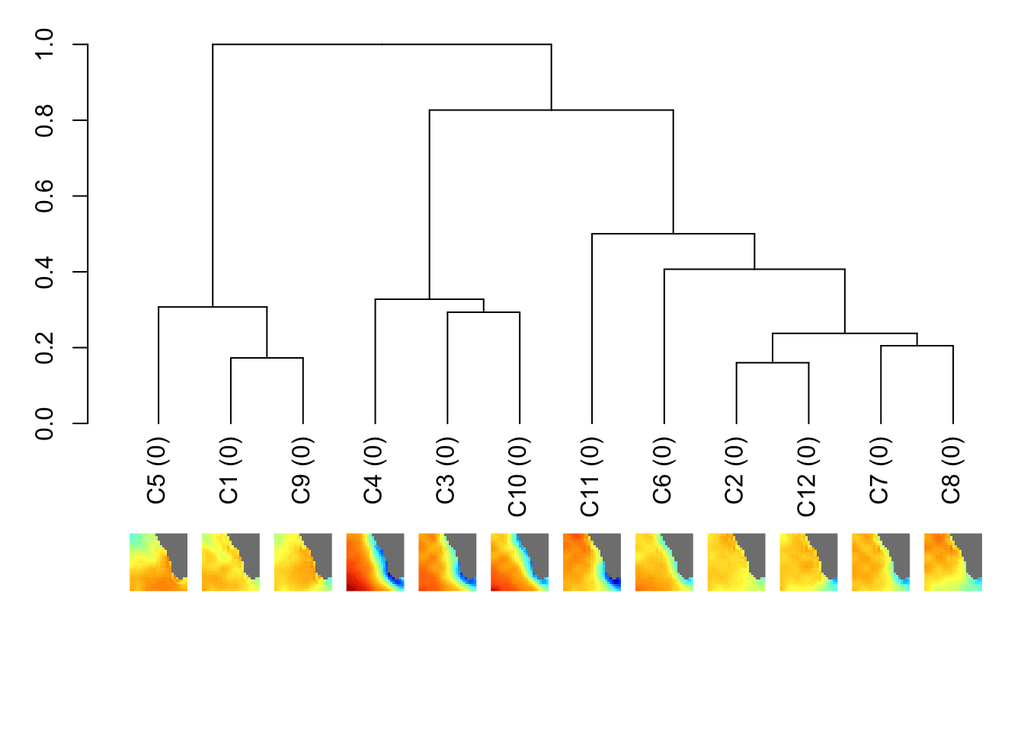

```r
dendIMG(CC, img.list.norm, type="original", pal=pal, scale.same=TRUE)
```

### Non-normed clusters

```r
CC <- out_kmeans$centers
labs <- paste0("C", 1:n_K, "  ", round(apply(CC,1,mean)-mean(CC),digits=1))
rownames(CC) <- labs
```

Distance based on correlation. In this case, the mean temperature of the centroid images are not important since correlation is scale invariate. So this distance is based on *shape*.

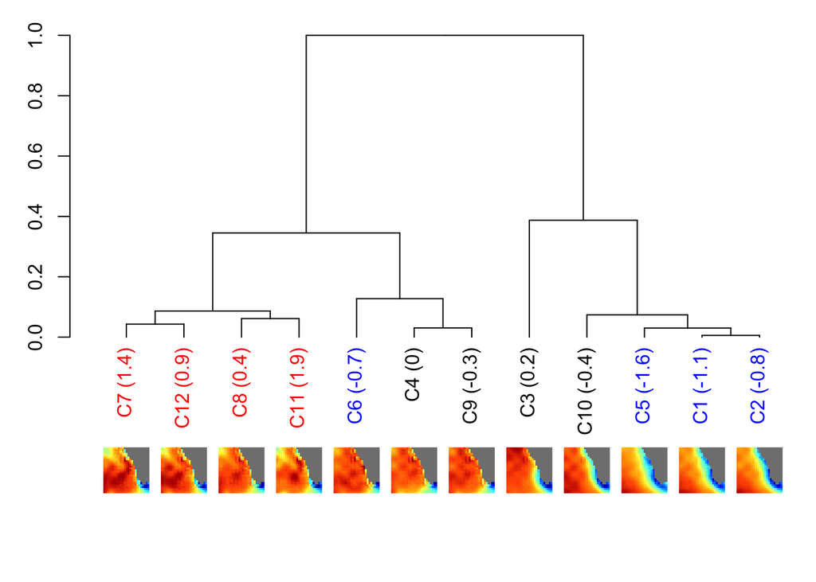

```r
dendIMG(CC, img.list.orig, type="correlation", pal=pal)
```

Here the distance is Euclidian. The first split of the tree is based on average temperature. In the labels, the number is the temperature of the centroid image relative to the mean over all centroids.

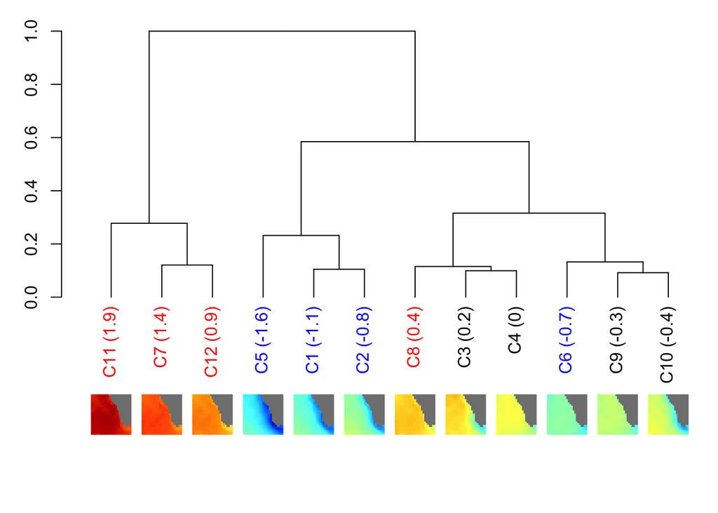

```r
dendIMG(CC, img.list.orig, type="original", pal=pal, scale.same=TRUE)
```

Removing the mean off the rows seems to capture the upwelling better. Images are shown for each centroid. Note, distance scaled to maximum of 1.

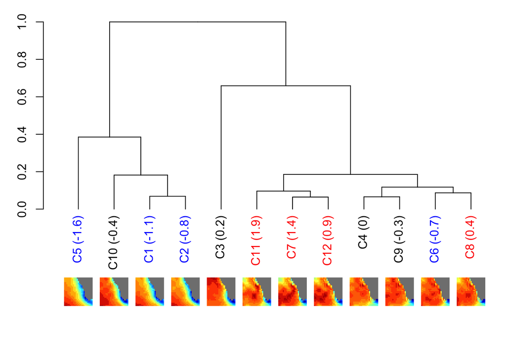

### Normed and variance standardized clusters

```r
CC <- out_kmeans_sd$centers
labs <- paste0("C", 1:n_K)
rownames(CC) <- labs
```

Distance based on correlation. The `dendIMG()` function is shown below.

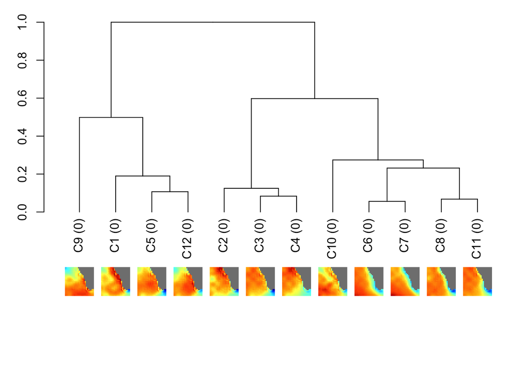

```r
dendIMG(CC, img.list.sd, type="correlation", pal=pal, scale.same=TRUE)
```

Here the distance is Euclidian.

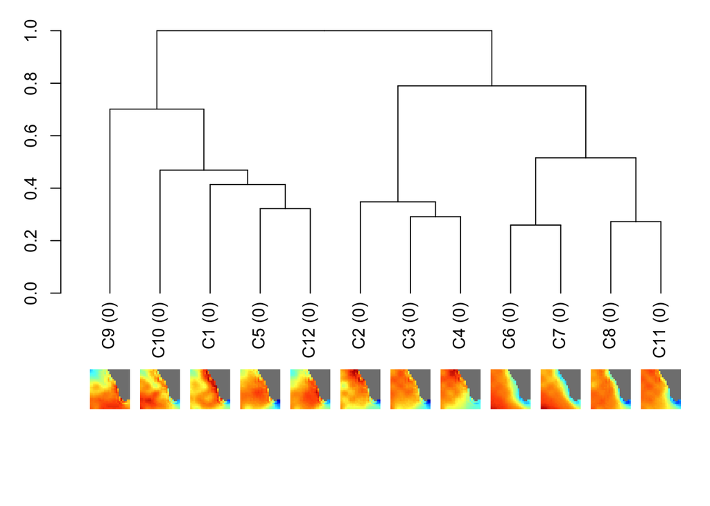

```r
dendIMG(CC, img.list.sd, type="original", pal=pal, scale.same=TRUE)
```

## Heat maps

We can make a heatmap of cluster by month and year, but this randomly assigns colors to our clusters. We want the colors to match the types of shapes, so that upwelling shapes (say), all have the same color.

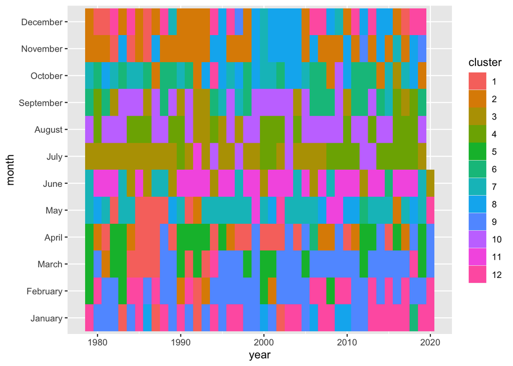

```r
library(ggplot2)
df <- data.frame(date=as.Date(names(out_kmeans_norm$cluster)), cluster=as.factor(out_kmeans_norm$cluster))
df$month <- factor(months(df$date), levels=month.name[c(1:12)])
df$year <- as.numeric(format(df$date,'%Y'))
ggplot(df, aes(x=year, y=month, fill= cluster)) + geom_tile()
```

### How to color the clusters?

If we look at the Normed clusters, they seem to fall into some main groups: upwelling with nearshore-offshore differential, cold tip, and cold north tongue. We can then divide these into smaller groups. The numbers in parentheses are the sd of the images.

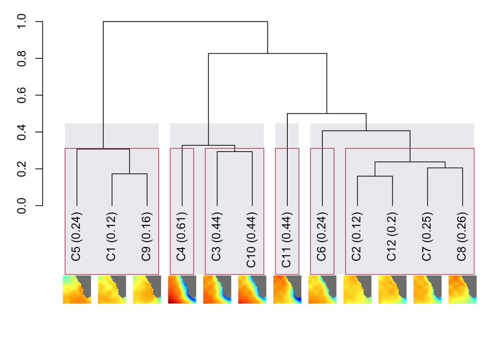

Much better! Color scheme is a bit wonky but we are getting the recoloring.

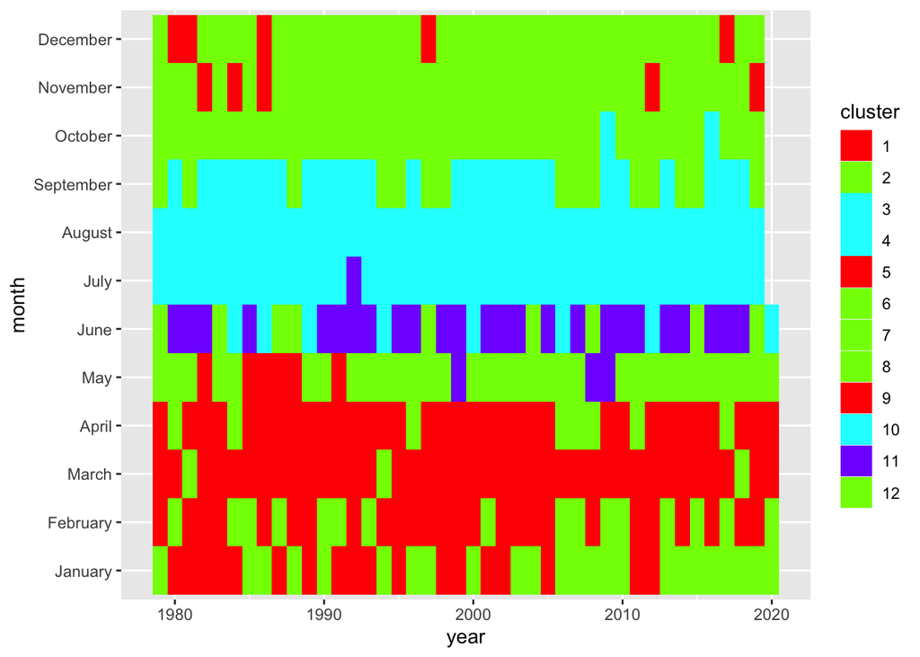

```r
group.colors <- rainbow(main.n)
dend.group <- cutree(dend, k=main.n)
img.group <- out_kmeans_norm$cluster
for(i in 1:length(dend.group)) img.group[img.group==i] <- dend.group[i]
df$main.group <- as.factor(img.group)
ggplot(df, aes(x=year, y=month, fill=cluster)) + geom_tile() +
  scale_fill_manual(values=group.colors[dend.group])
```

Now I will apply a color ramp within the main groups.

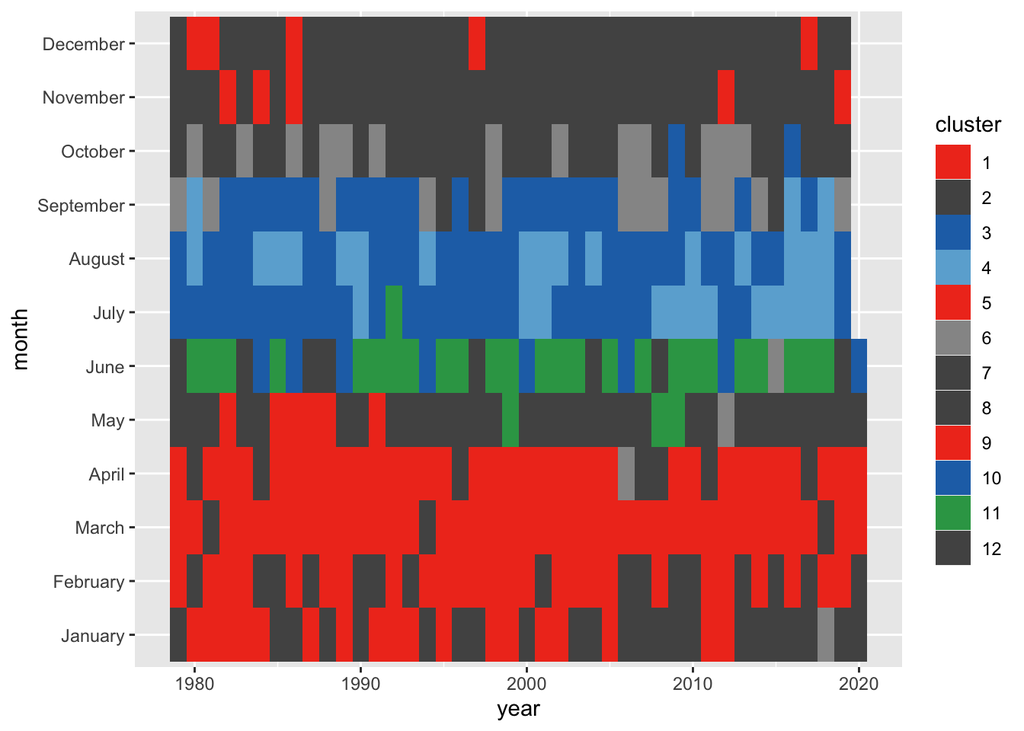

### Normed heatmaps

Here are a few different versions of heat maps.

Here I ramp based on the subgroups.

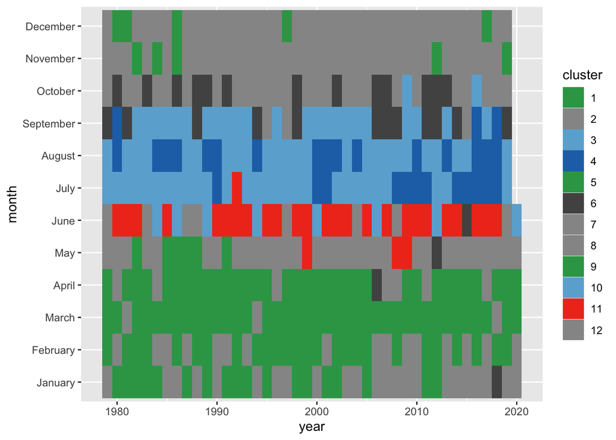

```r
myheatmap(dend, out_kmeans_norm, main.n=main.n, sub.n=sub.n, ramp="mean")
```

Here I show all clusters within the main groups and ramp is based on the variance. Darker colors equal higher variance. A lot of the centers have the same/similar variance so are the same shade.

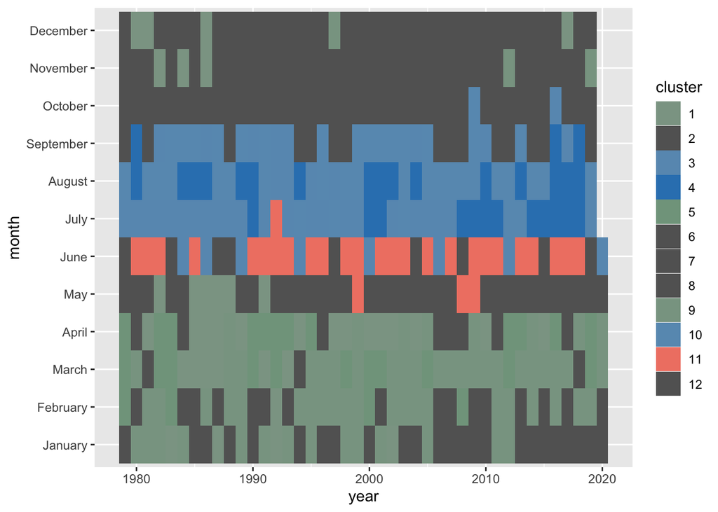

```r
myheatmap(dend, out_kmeans_norm, main.n=main.n, sub.n=n_K, ramp="var", ramp.type=2)
```

### Non-normed heatmaps

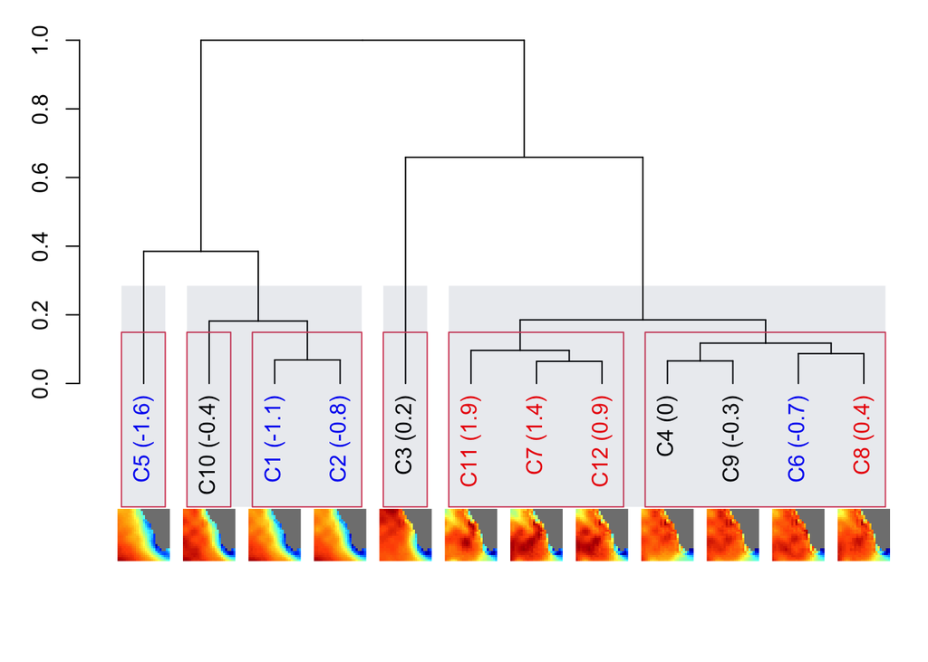

```r
CC <- out_kmeans$centers
labs <- paste0("C", 1:n_K, "  ", round(apply(CC,1,mean)-mean(CC),digits=1))
rownames(CC) <- labs
dend <- dendIMG(CC, img.list.orig, type="mean0", pal=pal, scale.same=FALSE)
rect.dendrogram(dend, sub.n, border = 2)
rect.dendrogram( dend, k=main.n, lty = 5, lwd = 0, col=rgb(0.1, 0.2, 0.4, 0.1) )
```

Here I ramp based on the subgroups. Within a subgroup, darker colors are warmer.

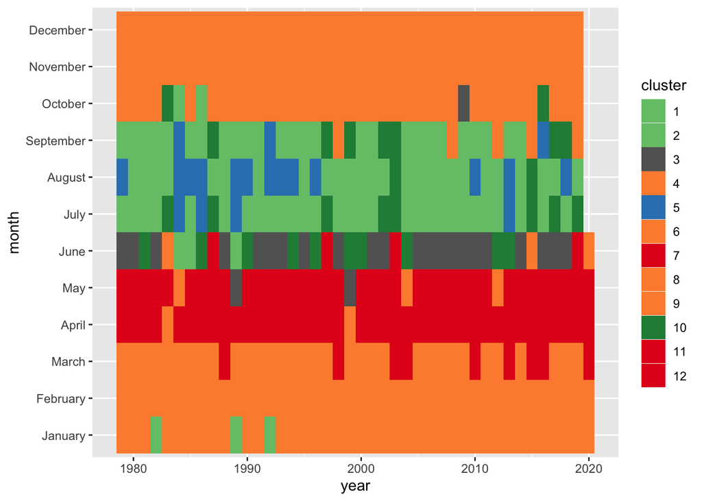

```r
myheatmap(dend, out_kmeans, main.n=main.n, sub.n=sub.n, ramp="mean")
```

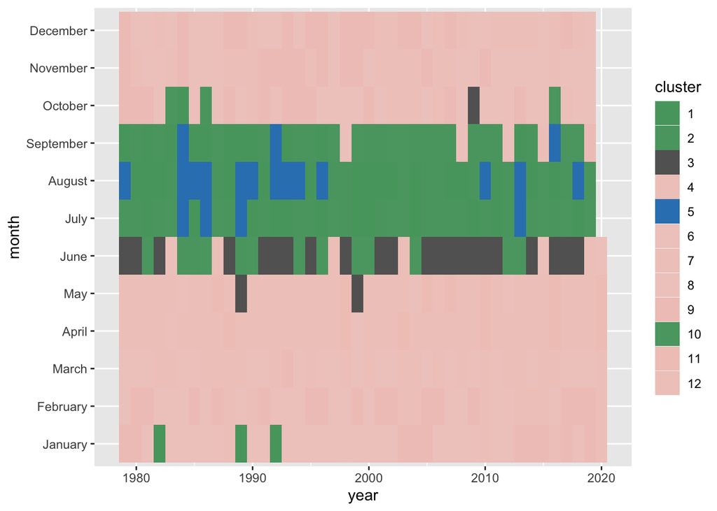

```r
myheatmap(dend, out_kmeans, main.n=main.n, sub.n=sub.n, ramp="var", ramp.type=2)
```

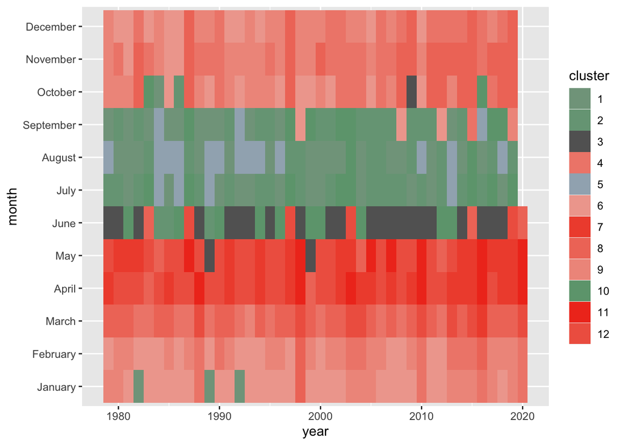

```r
myheatmap(dend, out_kmeans, main.n=main.n, sub.n=n_K, ramp="mean", ramp.type=2)
```

### Normed and variance standardized heatmaps

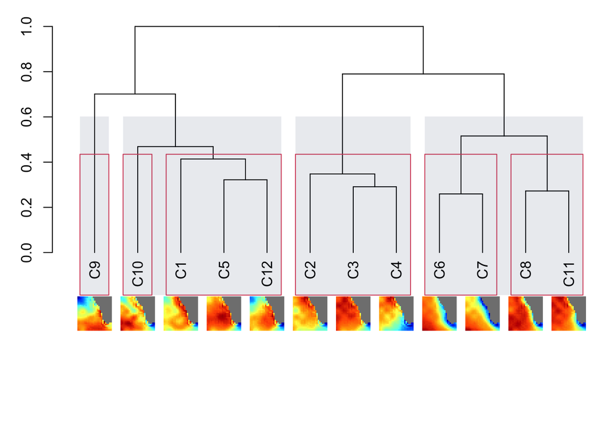

```r
CC <- out_kmeans_sd$centers
labs <- paste0("C", 1:n_K)
rownames(CC) <- labs
dend <- dendIMG(CC, img.list.sd, type="original", pal=pal, scale.same=FALSE, lab.extra = "none")
rect.dendrogram(dend, sub.n, border = 2)
rect.dendrogram( dend, k=main.n, lty = 5, lwd = 0, col=rgb(0.1, 0.2, 0.4, 0.1) )
```

Here I ramp based on the subgroups. Since the images are demeaned and variance standardized, I cannot ramp on either of those.

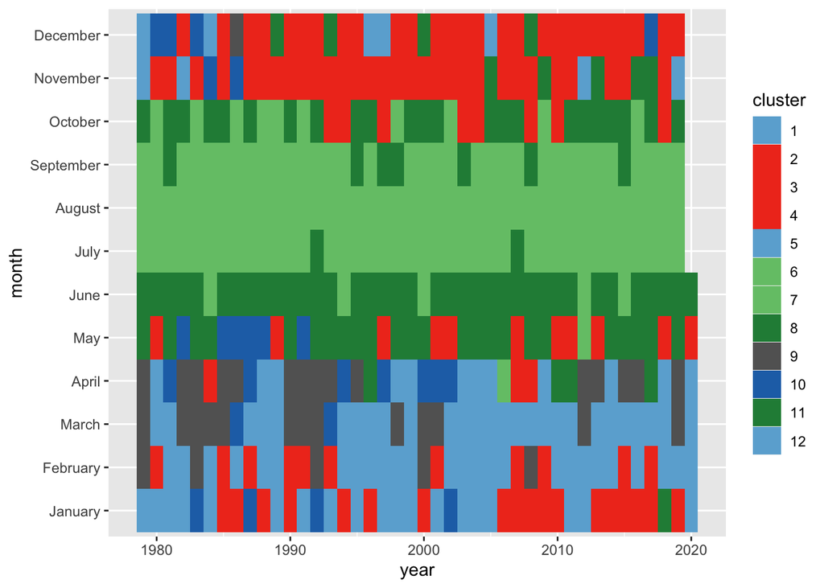

```r
myheatmap(dend, out_kmeans_sd, main.n=main.n, sub.n=sub.n, ramp="mean")
```

## functions

```
dendIMG <- function(centers, img.list, type=c("mean0", "original", "correlation"),
                    scale.same=FALSE, pal=colorRamps::matlab.like(20),
                    lab.extra=c("mean", "var", "none")){
  library(dendextend)
  n.K <- nrow(centers)
  lab.extra <- match.arg(lab.extra)
  if(lab.extra=="mean") labs <- paste0("C", 1:n.K, " (", round(apply(centers,1,mean)-mean(centers),digits=1),")")
  if(lab.extra=="var") labs <- paste0("C", 1:n.K, " (", round(sqrt(apply(centers,1,var)),digits=2),")")
  if(lab.extra=="none") labs <- paste0("C", 1:n.K)
  if(type=="original"){
    mat <- centers
    rownames(mat) <- labs
    dd <- dist(mat)
  }
  if(type=="mean0"){
    mat <- t(scale(t(centers), scale=FALSE))
    rownames(mat) <- labs
    dd <- dist(mat)
  }
  if(type=="correlation"){
    mat <- (1 - cor(t(centers)))/2
    rownames(mat) <- labs
    dd <- as.dist(mat)
  }
  dend <- as.dendrogram(hclust(dd/max(dd)))
  cols <- cut(apply(centers,1,mean)-mean(centers), breaks=c(-2,-0.4,0.4,2), labels=c("blue", "black", "red"))
  labels_colors(dend) <- as.character(cols)[order.dendrogram(dend)]
  # https://rstudio.com/wp-content/uploads/2016/10/how-big-is-your-graph.pdf
  par(mar=c(10,3,1,0), oma=rep(0,4))
  lab.width <- max(strwidth(paste0(labs,"a"), units="inches"))
  # y location of extent of labels
  plot(dend)
  user.range <- par("usr")[c(2,4)] - par("usr")[c(1,3)]
  in.to.usr <- par("pin")/user.range # in/usr ratio
  # images will be min inches ((0.8*par("pin")[1]/12.96), 0.8*in.to.usr[1])
  # don't go bigger than what image would be if x range were 12.96 (K=12)
  img.width.in <- min(0.8*par("pin")[1]/12.96, 0.8*in.to.usr[1])
  img.height.in <- img.width.in*nrow(img.list[[1]])/ncol(img.list[[1]])
  img.width.usr <- img.width.in/in.to.usr[1]
  img.height.usr <- img.height.in/in.to.usr[2]
  # top of the image in usr y measurement
  img.top.usr <- par("usr")[3] - lab.width/in.to.usr[2]
  img.bottom.usr <- img.top.usr - img.height.usr


  for(i in 1:n.K){
    if(scale.same==FALSE) img <- as.raster(img.list[[order.dendrogram(dend)[i]]], col=pal)
    if(scale.same==TRUE){
      d <- img.list[[order.dendrogram(dend)[i]]]
      a <- as.numeric(cut(values(d), breaks=seq(min(centers),(max(centers)),(max(centers)-min(centers))/length(pal))))
      img <- as.raster(img.list[[order.dendrogram(dend)[i]]], col=pal[min(a, na.rm=TRUE):max(a, na.rm=TRUE)])
    }
    img[is.na(img)] <- "#808080"
    #rasterImage(img, i-0.4, -.7, i+0.4, -.5, xpd=TRUE, lty=1, interpolate = FALSE)
    rasterImage(img, i-img.width.usr/2, img.top.usr, i+img.width.usr/2, img.bottom.usr, xpd=TRUE, lty=1, interpolate = FALSE)
  }
  invisible(dend)
}
```

```
myheatmap <- function(dend, kobject, main.n=3, sub.n=7, ramp=c("mean", "var"),
                      ramp.type=1){
  cluster <- kobject$cluster
  img.group <- kobject$cluster
  CC <- kobject$centers
  library(ggplot2)
  df <- data.frame(date=as.Date(names(cluster)), cluster=as.factor(cluster))
  df$month <- factor(months(df$date), levels=month.name[1:12])
  df$year <- as.numeric(format(df$date,'%Y'))

dend.group <- cutree(dend, k=sub.n)
for(i in 1:length(dend.group)) img.group[img.group==i] <- dend.group[i]
df$sub.group <- as.factor(img.group)

# Set up my palette; ramp within the main group
dend.group.main <- cutree(dend, k=main.n)
pal.sub <- rep(NA, attr(dend, "members"))
pals <- c("YlOrRd", "Greys", "Greens", "BuPu", "Blues")
pals[main.n] <- "Blues"
temps <- apply(CC,1,get(ramp))
main.temps <- tapply(temps, dend.group.main, mean)
tmp.main <- sort(main.temps, index.return=TRUE, decreasing=TRUE)$ix
if(ramp.type==1){
for(i in 1:main.n){
  main.group <- dend.group.main==tmp.main[i]
  sub.group <- unique(dend.group[main.group])
  cols <- rev(RColorBrewer::brewer.pal(max(3, length(sub.group)+2), pals[i]))
  sub.temps <- tapply(temps[main.group], dend.group[main.group], mean)
  tmp <- sort(sub.temps, index.return=TRUE, decreasing=TRUE)$ix
  for(j in 1:length(sub.group))
    pal.sub[dend.group==sub.group[tmp[j]]] <- cols[j]
}
}else{
  pal.sub <- rep(NA, main.n)
  main.temps <- tapply(apply(CC,1,mean), dend.group.main, mean)
  tmp.main <- sort(main.temps, index.return=TRUE, decreasing=TRUE)$ix
for(i in 1:main.n){
  pal.sub[tmp.main[i]] <- rev(RColorBrewer::brewer.pal(3, pals[i]))[1]
}
pal.sub <- pal.sub[dend.group.main]
temp.scaled <- 0.2+(temps-min(temps))/((max(temps)-min(temps))*1.25)
for(i in 1:length(pal.sub)) pal.sub[i] <- desat(pal.sub[i], sat=temp.scaled[i])
}

# Plot
ggplot(df, aes(x=year, y=month, fill= cluster)) + geom_tile() +
  scale_fill_manual(values=pal.sub)
}
```